# Part2

## PART 2: Tooth Growth (by Cimar)

## Introduction

In this section, I’ll explore the ToothGrowth dataset, from the datasets library, and run some tests to determine which variables affect one another.

## ToothGrowth data

```r
  library(datasets)
  dim(ToothGrowth)
```

```
## [1] 60  3
```

```r
  summary(ToothGrowth)
```

```
##       len        supp         dose
##  Min.   : 4.20   OJ:30   Min.   :0.500
##  1st Qu.:13.07   VC:30   1st Qu.:0.500
##  Median :19.25           Median :1.000
##  Mean   :18.81           Mean   :1.167
##  3rd Qu.:25.27           3rd Qu.:2.000
##  Max.   :33.90           Max.   :2.000
```

```r
  table(unlist(subset(ToothGrowth,supp=='OJ')$dose))
```

```
##
## 0.5   1   2
##  10  10  10
```

```r
  table(unlist(subset(ToothGrowth,supp=='VC')$dose))
```

```
##
## 0.5   1   2
##  10  10  10
```

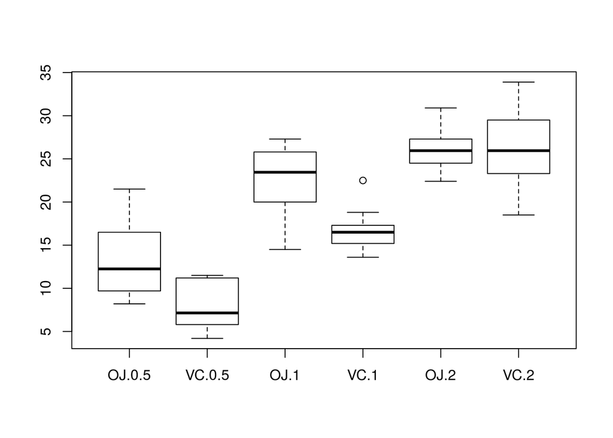

```r
  boxplot(len~supp*dose,data=ToothGrowth)
```

ToothGrowth contains 60 rows of data, in three columns. These columns are:

- ‘len’, numeric. len ranges from 4.2 to 33.9, with a median of 19.25, a mean of 18.81, and a standard deviation of 7.649. According to the documentation, len indicates the length of cells responsible for tooth growth in guinea pigs.
- ‘supp’, factor. Supp can have one of two values, ‘VC’ or ‘OJ.’ There are 30 rows of data for either supplement, evenly distributed between the three levels of dosage. According to the documentation, supp indicates the delivery method of Vitamin C, whic was being tested for its effect on tooth growth in guinea pigs.
- ‘dose’, numeric. Takes one of three values: 0.5, 1, or 2. There are 20 rows of data for each of these values. Those 20 are evenly split between the two supp. According to the doucmentation, indicates the dosage Vitamin C, tested on the teeth, delivered in either of the two supp.

We can use this data to easily test 3 questions

## Question 1: Is there a relationship between supp and len?

We use the column supp to split our dataset into two distributions, supp==“VC” and supp==“OJ”. By comparing the means of these distributions we test the null hypothesis “Supp does not have a significant relationship to len” or “mu_OJ = mu_VC.” We’ll set alpha = 0.05.

```r
t.test(subset(ToothGrowth,supp=='OJ')$len,subset(ToothGrowth,supp=='VC')$len,conf.level=.95)
```

```
##
##  Welch Two Sample t-test
##
## data:  subset(ToothGrowth, supp == "OJ")$len and subset(ToothGrowth, supp == "VC")$len
## t = 1.9153, df = 55.309, p-value = 0.06063
## alternative hypothesis: true difference in means is not equal to 0
## 95 percent confidence interval:
##  -0.1710156  7.5710156
## sample estimates:
## mean of x mean of y
##  20.66333  16.96333
```

According to our t-test, if supp does not have an effect on len (i.e. our null hypothesis is true), we expect to see distribution means this different with probability 6.063%. This is higher than our desired alpha of 0.05 (5%), so we fail to reject the null hypothesis. On the basis of this data, the two distributions are very likely to have the same mean. (We could also use the confidence interval, which includes a difference of 0 in its range, to fail to reject the null hypothesis)

## Question 2: Is there a relationship between dose and len?

We have 3 different confidence intervals. One way to test whether dose affects len is to computer 3 separate t-tests, comparing the distributions of length for each pair of dosage levels.

In each, our null hypothesis is “dose does not have a significant relationship to len” or “mu_dosage1 = mu_dosage2.”

```r
t.test(subset(ToothGrowth,dose==0.5)$len,subset(ToothGrowth,dose==1)$len,conf.level=.95)
```

```
##
##  Welch Two Sample t-test
##
## data:  subset(ToothGrowth, dose == 0.5)$len and subset(ToothGrowth, dose == 1)$len
## t = -6.4766, df = 37.986, p-value = 1.268e-07
## alternative hypothesis: true difference in means is not equal to 0
## 95 percent confidence interval:
##  -11.983781  -6.276219
## sample estimates:
## mean of x mean of y
##    10.605    19.735
```

```r
t.test(subset(ToothGrowth,dose==0.5)$len,subset(ToothGrowth,dose==2)$len,conf.level=.95)
```

```
##
##  Welch Two Sample t-test
##
## data:  subset(ToothGrowth, dose == 0.5)$len and subset(ToothGrowth, dose == 2)$len
## t = -11.799, df = 36.883, p-value = 4.398e-14
## alternative hypothesis: true difference in means is not equal to 0
## 95 percent confidence interval:
##  -18.15617 -12.83383
## sample estimates:
## mean of x mean of y
##    10.605    26.100
```

```r
t.test(subset(ToothGrowth,dose==1)$len,subset(ToothGrowth,dose==2)$len,conf.level=.95)
```

```
##
##  Welch Two Sample t-test
##
## data:  subset(ToothGrowth, dose == 1)$len and subset(ToothGrowth, dose == 2)$len
## t = -4.9005, df = 37.101, p-value = 1.906e-05
## alternative hypothesis: true difference in means is not equal to 0
## 95 percent confidence interval:
##  -8.996481 -3.733519
## sample estimates:
## mean of x mean of y
##    19.735    26.100
```

Every one of these t-tests returned a p-value under alpha. According to our tests, if the true means were equal, these particular distributions would occur far less than a tenth of a percent of the time. Thus we can reject the null hypotheses. A difference in dose seems to, indeed, correlate with a difference in length. In every case, the distribution with the higher dose had a significantly greater mean length.

## Question 3: Holding dose constant, is there a relationship between supp and len?

Last of all, we can perform another three t-tests, comapring lenghts for either supp within each level of dose.

In each, our null hypothesis is “holding dose constant, supp does not have a significant relationship to len” or “mu_d_s1 = mu_d_s2.”

```r
t.test(subset(subset(ToothGrowth,dose==0.5),supp=='OJ')$len,subset(subset(ToothGrowth,dose==0.5),supp=='VC')$len,conf.level=.95)
```

```
##
##  Welch Two Sample t-test
##
## data:  subset(subset(ToothGrowth, dose == 0.5), supp == "OJ")$len and subset(subset(ToothGrowth, dose == 0.5), supp == "VC")$len
## t = 3.1697, df = 14.969, p-value = 0.006359
## alternative hypothesis: true difference in means is not equal to 0
## 95 percent confidence interval:
##  1.719057 8.780943
## sample estimates:
## mean of x mean of y
##     13.23      7.98
```

```r
t.test(subset(subset(ToothGrowth,dose==1),supp=='OJ')$len,subset(subset(ToothGrowth,dose==1),supp=='VC')$len,conf.level=.95)
```

```
##
##  Welch Two Sample t-test
##
## data:  subset(subset(ToothGrowth, dose == 1), supp == "OJ")$len and subset(subset(ToothGrowth, dose == 1), supp == "VC")$len
## t = 4.0328, df = 15.358, p-value = 0.001038
## alternative hypothesis: true difference in means is not equal to 0
## 95 percent confidence interval:
##  2.802148 9.057852
## sample estimates:
## mean of x mean of y
##     22.70     16.77
```

```r
t.test(subset(subset(ToothGrowth,dose==2),supp=='OJ')$len,subset(subset(ToothGrowth,dose==2),supp=='VC')$len,conf.level=.95)
```

```
##
##  Welch Two Sample t-test
##
## data:  subset(subset(ToothGrowth, dose == 2), supp == "OJ")$len and subset(subset(ToothGrowth, dose == 2), supp == "VC")$len
## t = -0.046136, df = 14.04, p-value = 0.9639
## alternative hypothesis: true difference in means is not equal to 0
## 95 percent confidence interval:
##  -3.79807  3.63807
## sample estimates:
## mean of x mean of y
##     26.06     26.14
```

The tests where dose is held constant to 0.5, and 1 are significant at the level of p<.01. This means that for these lower levels of dose, we reject the null hypotheses that distributions of different supplements have the same mean. The third test, where dose is held constant to 2, returns a p-value of .9639, so we fail to reject the null hypothesis at dose=2.

## Conclusions

Each of our tests was a t-test. The t-test depends on the assumptions that the true populations sampled follow a normal distribution, and were randomly, independently sampled. There are also requirements on the design of the study, but those are unrelated to the statistical relationship of these variables

We can conclude that there is a relationship between dose and len, as a higher dose was significantly correlated to longer tooth growth cells. We can also conclude that, holding dose constant, supp has a relationship to len for lower dosages (.5,1). ‘OJ’ tends to greater len than ‘VC’. At dose=2, possibly because the effect maxes out, no significant difference between the len for either supp is seen.